# Visualização de gráficos

Implementação dos tipos de gráficos mais utilizados em análise de dados estatísticos

Diego Maia

# 1 Scatterplots

[output not shown]

[output not shown]

[output not shown]

[figure not shown]

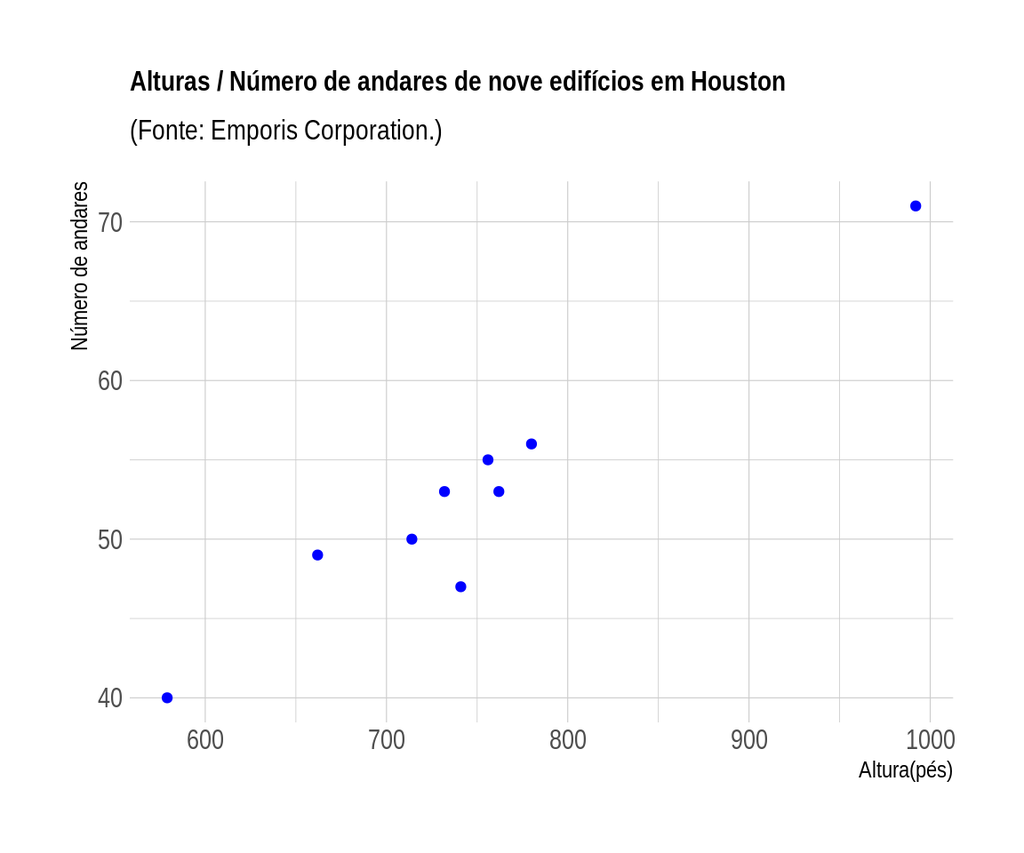

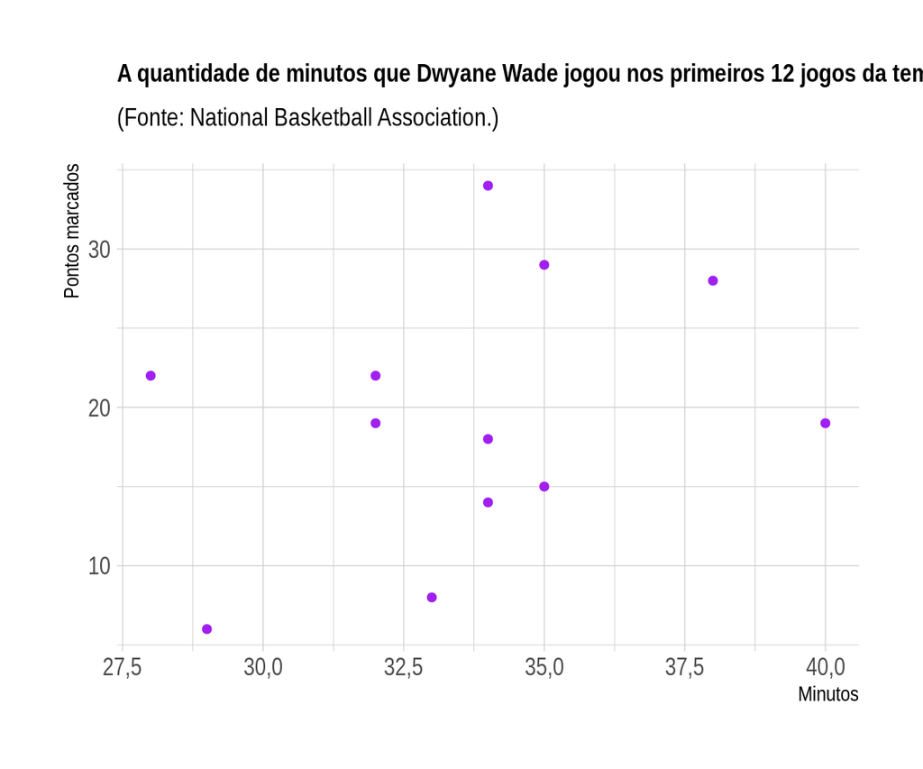

De acordo com o gráfico e com informações obtidas da tabela, a média de pontos marcados do jogador Dwyane Wade, quando ele atuou de 34 minutos(mediana) para mais, é um pouco superior à média da primeira metade. A média de pontos calculada na primeira metade dos valores de x(minutos) foi de 18.3, enquanto a média calculada na segunda metade foi de 20.6. Portanto, quando ele esteve por mais tempo em quadra a média de pontos dele acresceu.

# 2 Histogramas

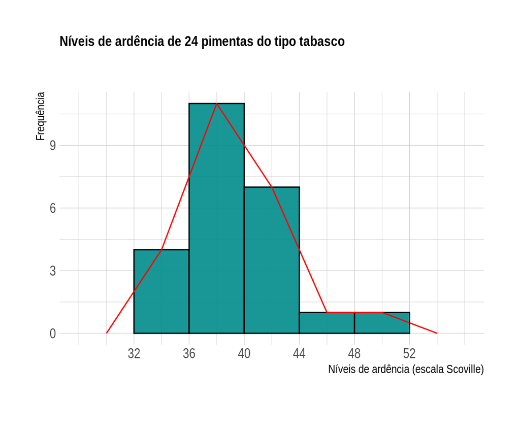

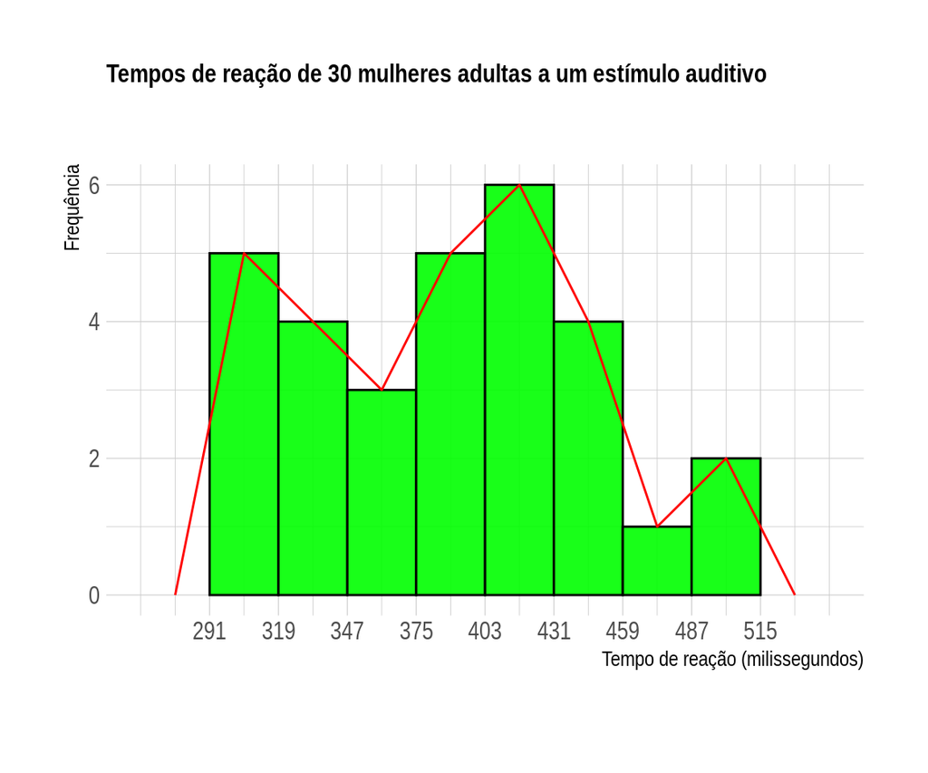

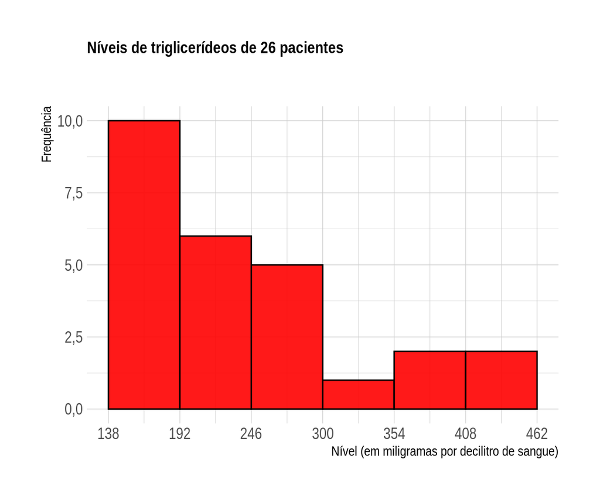

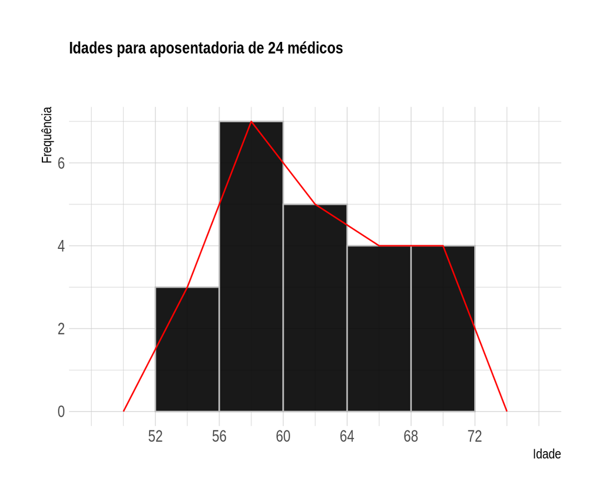

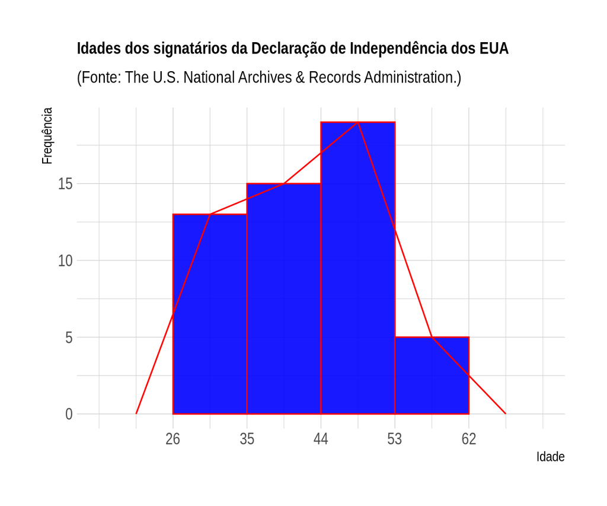

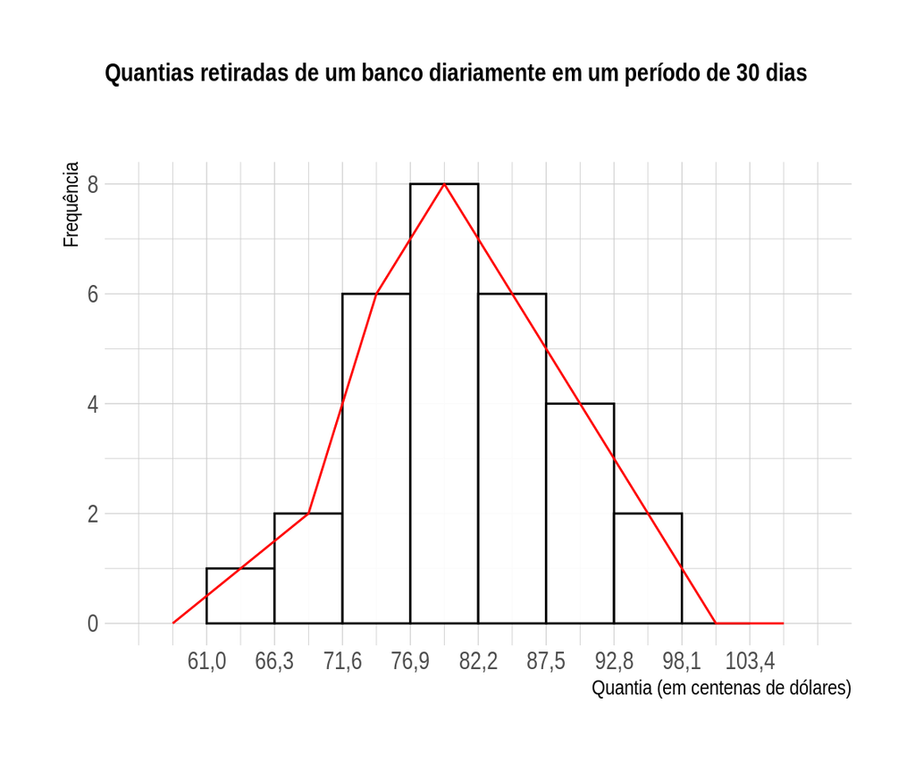

# 3 Boxplots

```
##     QtdHoras
##  Min.   :0,000
##  1st Qu.:2,000
##  Median :4,000
##  Mean   :3,786
##  3rd Qu.:5,000
##  Max.   :9,000
```

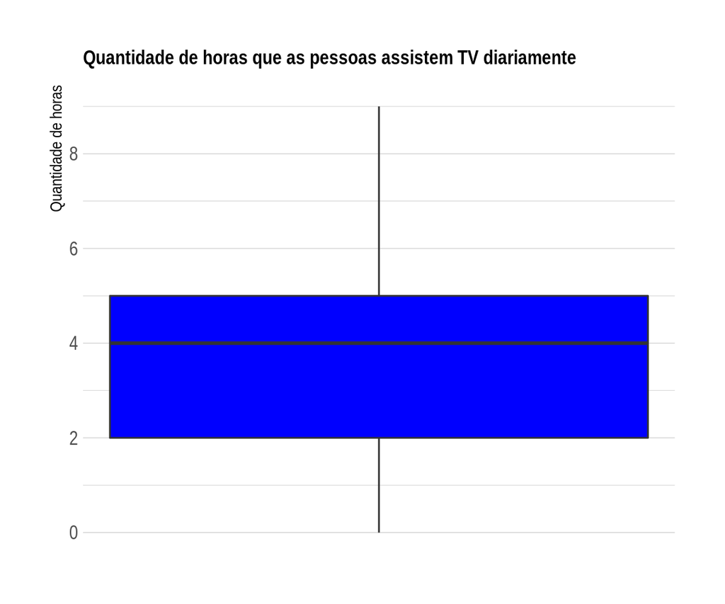

75% das pessoas assistem não mais que 5 horas de televisão por dia.

```
##     Trajeto
##  Min.   :1,800
##  1st Qu.:3,050
##  Median :3,850
##  Mean   :4,027
##  3rd Qu.:5,150
##  Max.   :6,000
```

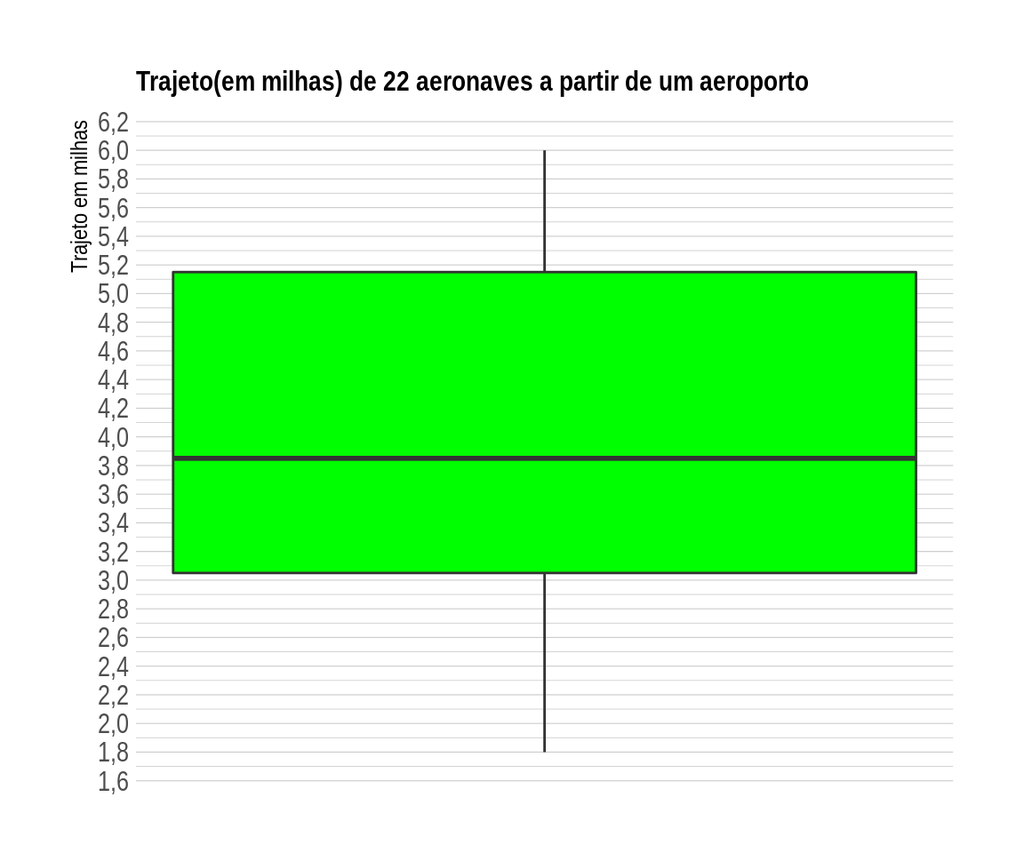

# 4 Barras e colunas

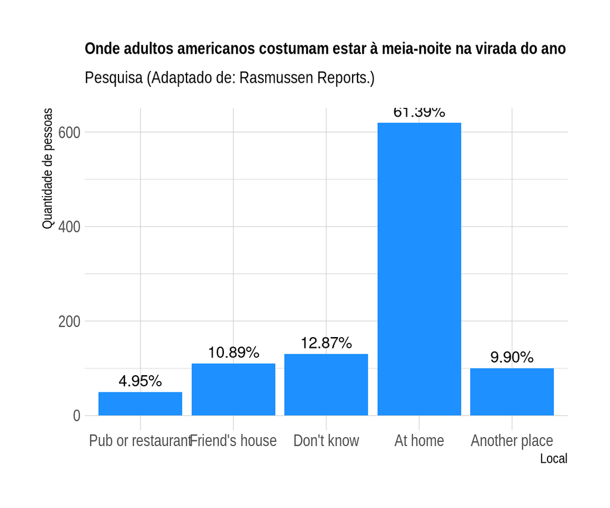

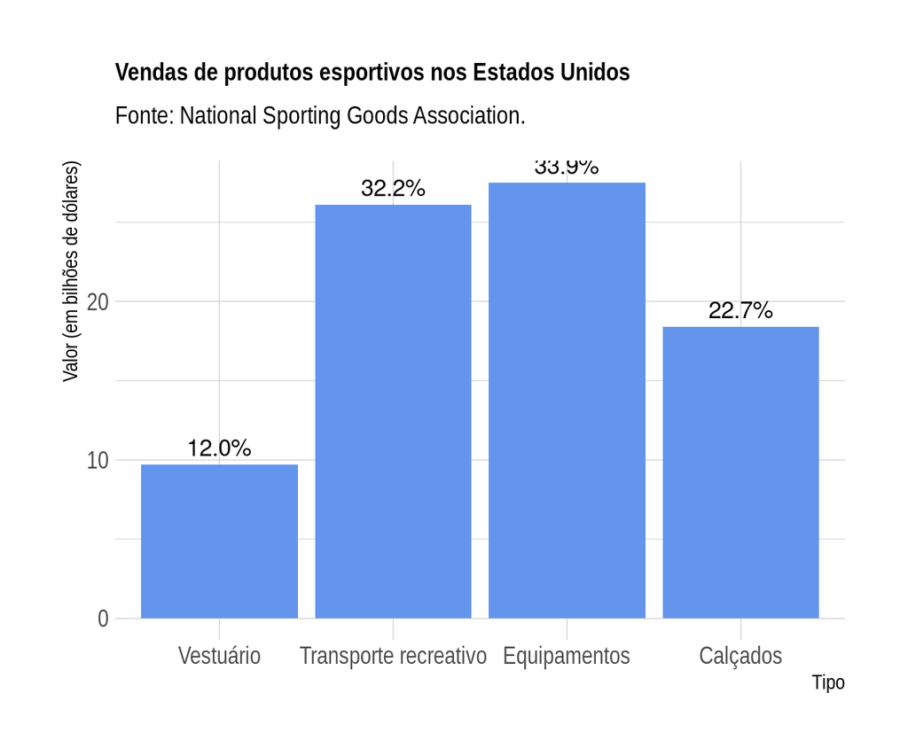

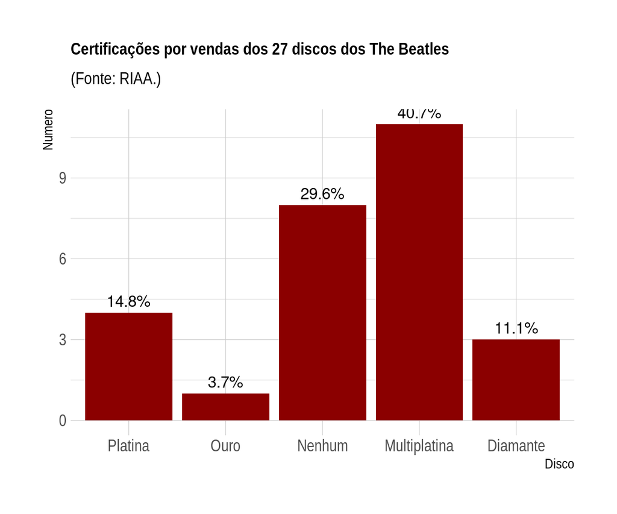

# 5 Linhas

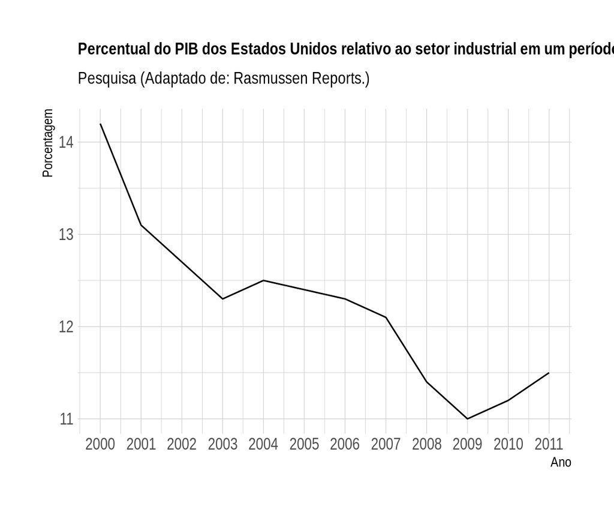

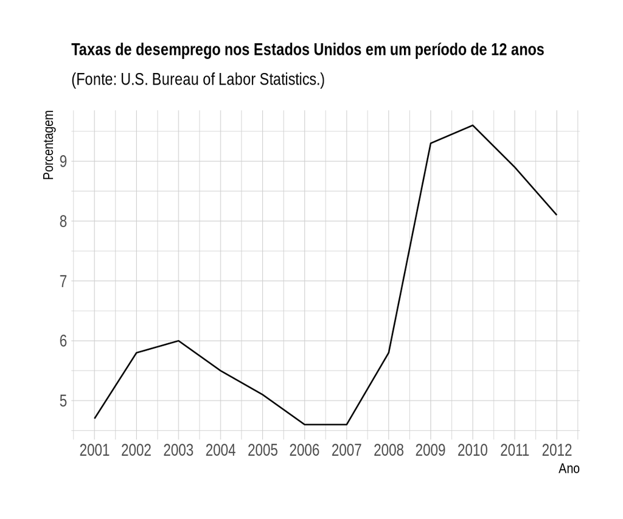

Certamente, um dos principais fatores que eleveram a taxa de desemprego nos EUA durante o período de 2007 à 2010 foi a crise econômica que o país sofreu devido à quebra do tradicional banco de investimento Lehman Brothers e de vários outros bancos em um efeito dominó.